# Using machine learning to build a model of Eldritch Horror outcomes

Keith H. Turner (khturner@gmail.com, http://twitter.com/kay_aych)

12/31/2015

## Intro

I love [Eldritch Horror](https://www.fantasyflightgames.com/en/products/eldritch-horror/). The flavor text is so evocative, the sense of accomplishment when you finally bury a mystery is so satisfying, and the dread you feel as the next Mythos card is revealed is just delicious. You really feel like the world of the game is out to get you. However, it does feel like sometimes it’s out to get you more than other times, doesn’t it? Sometimes you’re just cruising through the world, snatching up clues and mysteries like it’s merely a bump on the road to getting cool items. After our fourth win in a row, my game group and I started to wonder if we were doing something wrong, or if there were ways we could make the game more challenging.

A member of my game group came across this great [Google Doc of Eldritch Horror outcomes](https://docs.google.com/spreadsheets/d/1ZdxFQZu-5jT9zyTRuE0JCFR4KmlRSMTx1G0bZntfdWA/edit#gid=3), and it got my data scientist wheels turning. The Doc has a lot of good summary statistics with some general guidelines to follow if you want to design an easier (Daisy, Ursula, Agnes, and George vs. Rise of the Elder Things on the Mountains of Madness sideboard) or a harder (Mark, Leo, Silas, Akachi, and Lily vs. Yig with the Forsaken Lore expansion) game. Though what really caught my eye was the last worksheet on the Doc - the raw data. I got to wondering - can machine learning find patterns in the data and build a more complete model of Eldritch Horror outcomes? Below, I’ll walk through my investigations, but there are a few key take-home points that stood out to me.

## Take-home points

- The key factors in determining game difficulty are the team size and the Ancient One (check the Google Doc for guidelines there)
- The expansions do modify the difficulty, with Mountains of Madness actually making the game easier (I suppose it’s all those cool artifacts and Active Mystery advancements you get for trudging around Antarctica)
- Most importantly, it is **hard** to predict the outcome of an Eldritch Horror game based on the setup, which I was pleased to find. After all, what fun is a game (or anything, for that matter!) where you have no agency, and the outcome is predetermined for you?

## Interactive predictor

You can find an interactive version of the model at http://khturner.shinyapps.io/EldritchML. Have fun!

## Loading the data

I decided to play with the data in my sandbox of choice, R. I tend to do everything in R with the amazing [dplyr](https://cran.r-project.org/web/packages/dplyr/index.html) package, so if you are not familiar with some of what I’m doing I’d recommend the excellent [intro vignette](https://cran.rstudio.com/web/packages/dplyr/vignettes/introduction.html). The first step is to get the game data in:

```r
suppressPackageStartupMessages(require(dplyr))
suppressPackageStartupMessages(require(googlesheets))
# Read in the spreadsheet
games <- "https://docs.google.com/spreadsheets/d/1ZdxFQZu-5jT9zyTRuE0JCFR4KmlRSMTx1G0bZntfdWA/edit#gid=40" %>%
  gs_url %>% gs_read("Submissions")
```

```
## Sheet-identifying info appears to be a browser URL.
## googlesheets will attempt to extract sheet key from the URL.
## Putative key: 1ZdxFQZu-5jT9zyTRuE0JCFR4KmlRSMTx1G0bZntfdWA
## Authentication will be used.
## Sheet successfully identifed: "Eldritch Horror Statistics"
## Accessing worksheet titled "Submissions"
```

```r
# Let's take a look
games
```

```
## Source: local data frame [4,791 x 18]
##
##              Timestamp Ancient.One Expansions Mythos.modification Options
##                  (chr)       (chr)      (chr)               (chr)   (chr)
## 1  11/22/2013 19:17:25    Azathoth         NA                None      NA
## 2  11/22/2013 19:17:39     Cthulhu         NA                None      NA
## 3  11/22/2013 19:18:55    Azathoth         NA                None      NA
## 4  11/22/2013 21:46:16 Yog-Sothoth         NA                None      NA
## 5  11/22/2013 21:47:19     Cthulhu         NA                None      NA
## 6   11/23/2013 3:21:04    Azathoth         NA                None      NA
## 7  11/23/2013 20:12:23    Azathoth         NA        Hard removed      NA
## 8  11/23/2013 23:29:36    Azathoth         NA                None      NA
## 9  11/24/2013 21:39:12    Azathoth         NA                None      NA
## 10  11/25/2013 1:53:26    Azathoth         NA                None      NA
## ..                 ...         ...        ...                 ...     ...
## Variables not shown: Result (chr), Score (chr), Doom.track (chr),
##   Team.Size (int), Defeated (chr), Devoured (chr), Investigators (chr),
##   Special.Events (chr), Epic.Monsters (chr), Game.Length (chr),
##   Rumors.Passed (chr), Rumors.Failed (chr), Nickname (chr)
```

The data is a bit messy, and includes some variables that we’re not interested in feeding into our model of game setup (playtime for instance). Let’s clean it up.

```r
# Tidy up columns with some entries are named differently
games$Mythos.modification[which(games$Mythos.modification == "Only Easy used")] <- "Easy only"
games$Mythos.modification[which(games$Mythos.modification == "Only Hard used")] <- "Hard only"
games$Result[which(games$Result == "Defeat by Awakened Ancient One")] <- "Defeat by awakened Ancient One"
games <- games %>%
  # Factorize variables that should be factors
  mutate(Ancient.One = factor(Ancient.One), Mythos.modification = factor(Mythos.modification),
         Result = factor(Result), Team.Size = factor(Team.Size),
         # Let's make a Win/Lose factor
         Outcome = factor(gsub(" .*", "", Result)),
         # Break out lists into boolean columns
         Forsaken.Lore = grepl("Forsaken Lore", Expansions),
         Mountains.of.Madness = grepl("Mountains of Madness", Expansions),
         Strange.Remnants = grepl("Strange.Remnants", Expansions),
         Prelude = grepl("Prelude", Options), Starting.rumor = grepl("Starting Rumor", Options)) %>%
  # Remove variables that we don't want in our model, and clean out those list variables
  select(-Timestamp, -Nickname, -Options, -Expansions, -Special.Events, -Score, -Doom.track,
         -Defeated, -Devoured, -Game.Length, -Epic.Monsters, -Rumors.Passed, -Rumors.Failed)
# How's it look now?
games
```

```
## Source: local data frame [4,791 x 11]
##
##    Ancient.One Mythos.modification                         Result
##         (fctr)              (fctr)                         (fctr)
## 1     Azathoth                None   Victory by slumber Mysteries
## 2      Cthulhu                None   Victory by slumber Mysteries
## 3     Azathoth                None Defeat by awakened Ancient One
## 4  Yog-Sothoth                None   Victory by slumber Mysteries
## 5      Cthulhu                None          Defeat by elimination
## 6     Azathoth                None Defeat by awakened Ancient One
## 7     Azathoth        Hard removed              Defeat by forfeit
## 8     Azathoth                None   Victory by slumber Mysteries
## 9     Azathoth                None   Victory by slumber Mysteries
## 10    Azathoth                None   Victory by slumber Mysteries
## ..         ...                 ...                            ...
## Variables not shown: Team.Size (fctr), Investigators (chr), Outcome
##   (fctr), Forsaken.Lore (lgl), Mountains.of.Madness (lgl),
##   Strange.Remnants (lgl), Prelude (lgl), Starting.rumor (lgl)
```

OK, that looks better. The things that should be factors are, and we are starting to build boolean features for binary choices (e.g. “should we use Forsaken Lore, yes or no?”). This is starting to feel like a well-behaved dataset. The only column left that needs a little TLC is Investigators. This is a tough one to model. Team balance can definitely impact the game, but there are far too many unique combinations of investigators to consider each group as a level in a factor:

```r
games %>% group_by(Investigators) %>% tally(sort = T)
```

```
## Source: local data frame [2,738 x 2]
##
##        Investigators     n
##                (chr) (int)
## 1                 NA   195
## 2      Charlie, Lily    21
## 3          Leo, Lily    21
## 4      Akachi, Silas    19
## 5        Diana, Lily    19
## 6  Jacqueline, Trish    18
## 7      Diana, Norman    17
## 8         Jim, Trish    17
## 9                Leo    17
## 10      Akachi, Lily    16
## ..               ...   ...
```

```r
# I ain't got time for incomplete records!
games <- games %>% filter(!is.na(Investigators))
```

2,737 different logged teams is a lot of levels for a factor, so clearly we need to distill this down somewhat. Let’s do the dumbest thing first, make a boolean column for each investigator:

```r
all_investigators <- games$Investigators %>% strsplit(", ") %>%
  unlist %>% factor %>% levels %>% gsub("\"", "", .)
for (investigator in all_investigators) {
  games[[investigator]] <- grepl(investigator, games$Investigators)
}
games <- games %>% select(-Investigators)
games
```

```
## Source: local data frame [4,596 x 34]
##
##    Ancient.One Mythos.modification                         Result
##         (fctr)              (fctr)                         (fctr)
## 1     Azathoth                None   Victory by slumber Mysteries
## 2      Cthulhu                None   Victory by slumber Mysteries
## 3     Azathoth                None Defeat by awakened Ancient One
## 4  Yog-Sothoth                None   Victory by slumber Mysteries
## 5      Cthulhu                None          Defeat by elimination
## 6     Azathoth                None Defeat by awakened Ancient One
## 7     Azathoth        Hard removed              Defeat by forfeit
## 8     Azathoth                None   Victory by slumber Mysteries
## 9     Azathoth                None   Victory by slumber Mysteries
## 10    Azathoth                None   Victory by slumber Mysteries
## ..         ...                 ...                            ...
## Variables not shown: Team.Size (fctr), Outcome (fctr), Forsaken.Lore
##   (lgl), Mountains.of.Madness (lgl), Strange.Remnants (lgl), Prelude
##   (lgl), Starting.rumor (lgl), Agnes (lgl), Akachi (lgl), Charlie (lgl),
##   Daisy (lgl), Diana (lgl), Finn (lgl), George (lgl), Jacqueline (lgl),
##   Jim (lgl), Leo (lgl), Lily (lgl), Lola (lgl), Marie (lgl), Mark (lgl),
##   Norman (lgl), Patrice (lgl), Silas (lgl), Skids (lgl), Tommy (lgl), Tony
##   (lgl), Trish (lgl), Ursula (lgl), Wilson (lgl), Zoey (lgl)
```

Alright, this is starting to look good. Let’s save our data so far and get to work!

```r
saveRDS(games, "EldritchData.rds.gz", compress = T)
```

## Model 0: You always lose

Let’s remove “Result” if we’re going to build a model of “Outcome” (it’s pretty easy to predict Victory or Defeat if you know you were Defeated by an awakened Ancient One)

```r
games <- games %>% select(-Result)
```

OK, to start, think of how you might begin to predict outcome based on setup. Let’s start by assuming that this game is evil and you lose every time. How accurate are we?

```r
Prediction <- rep("Defeat?", nrow(games))
# How accurate are we?
table(Prediction, games$Outcome) %>% prop.table
```

```
##
## Prediction    Defeat   Victory
##    Defeat? 0.4919495 0.5080505
```

OK, so the “you always lose” model is **49.2% accurate**, slightly worse than a coin flip. We can do better.

## Model 1: Ancient One + team size

We know from the Google Doc that some things, like the choice of Ancient One and team size, affect the game’s difficulty. So let’s have a look at that.

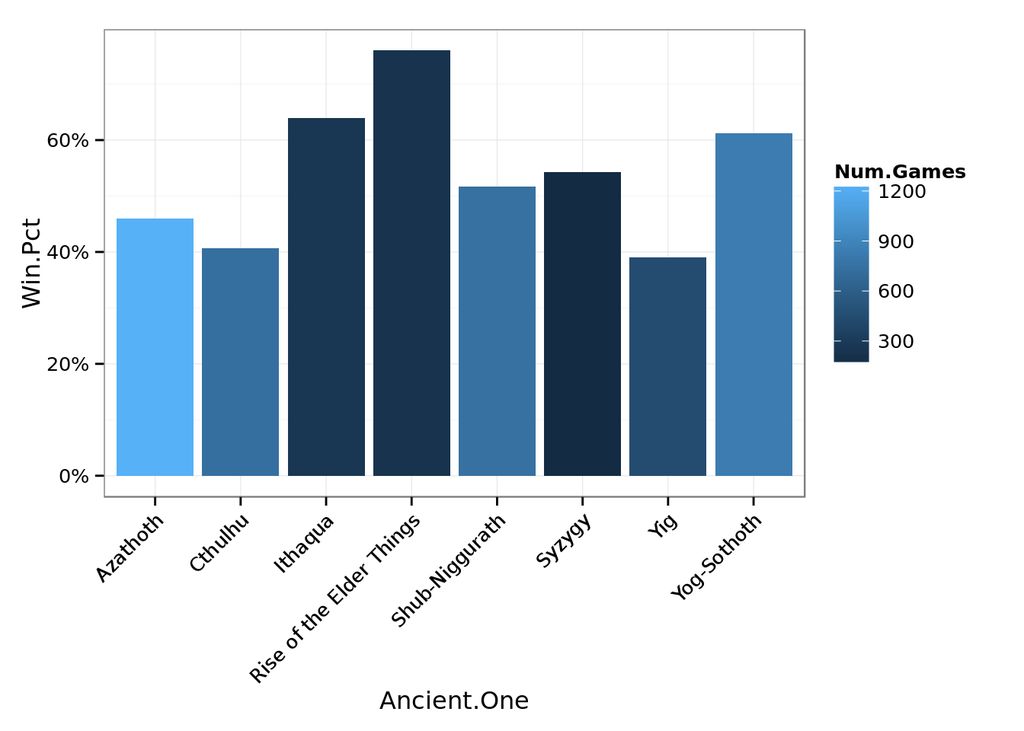

```r
suppressPackageStartupMessages(require(reshape2))
suppressPackageStartupMessages(require(ggplot2))
suppressPackageStartupMessages(require(scales))
games %>% group_by(Ancient.One, Outcome) %>% tally() %>% dcast(Ancient.One ~ Outcome, value.var = "n") %>%
  group_by(Ancient.One) %>% summarize(Win.Pct = Victory / (Defeat + Victory), Num.Games = Defeat + Victory) %>%
  ggplot(aes(Ancient.One, Win.Pct, fill = Num.Games)) + geom_bar(stat = "identity") + theme_bw() +
  theme(axis.text.x = element_text(angle = 45, hjust = 1)) + scale_y_continuous(labels = percent)
```

In this graph, the lighter colored bars are the Ancient Ones who are played more often. Turns out I’m not the only one who thinks Rise of the Elder Things is too easy! How about team size?

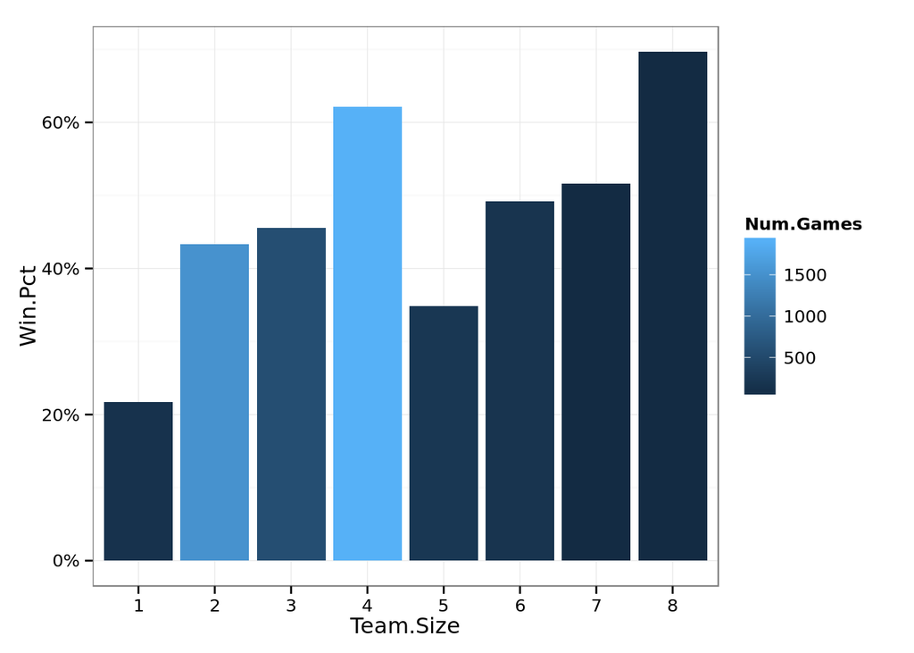

```r
games %>% group_by(Team.Size, Outcome) %>% tally() %>% dcast(Team.Size ~ Outcome, value.var = "n") %>%
  group_by(Team.Size) %>% summarize(Win.Pct = Victory / (Defeat + Victory), Num.Games = Defeat + Victory) %>%
  ggplot(aes(Team.Size, Win.Pct, fill = Num.Games)) + geom_bar(stat = "identity") + theme_bw() +
  scale_y_continuous(labels = percent)
```

The bar coloring is the same as before. Most people (us included) play as four, it turns out, which actually seems to make the game significantly easier. However, there’s a drop from 4 to 5. This is probably because with more investigators, you have to deal with more gates, more monsters during monster surges, and there are several rumors and mysteries that make you do something a number of times equal to the number of investigators, so now you have to do more work too.

Anyway, the point of all this was to come up with a better classifier than “you always lose”. How about we assume that you’ll lose the game if you play with 1, 2, 3, 5, or 6 investigators, or if you play against Azathoth, Cthulhu, or Yig (These are the bars in the two graphs above that are < 50% chance to win)?

```r
Prediction <- rep("Victory?", nrow(games))
Prediction[which(games$Team.Size %in% c(1,2,3,5,6) | games$Ancient.One %in% c("Azathoth", "Cthulhu", "Yig"))] <-
  "Defeat?"
table(Prediction, games$Outcome) %>% prop.table %>% diag %>% sum
```

```
## [1] 0.574195
```

Better! Overall accuracy is **57.4%**, up from 50%. Not too shabby. Now let’s tweak this further by looking at how different variables interact. For instance, Azathoth and Cthulhu are both pretty tough, but does the number of investigators affect win percentage differently for different Ancient Ones?

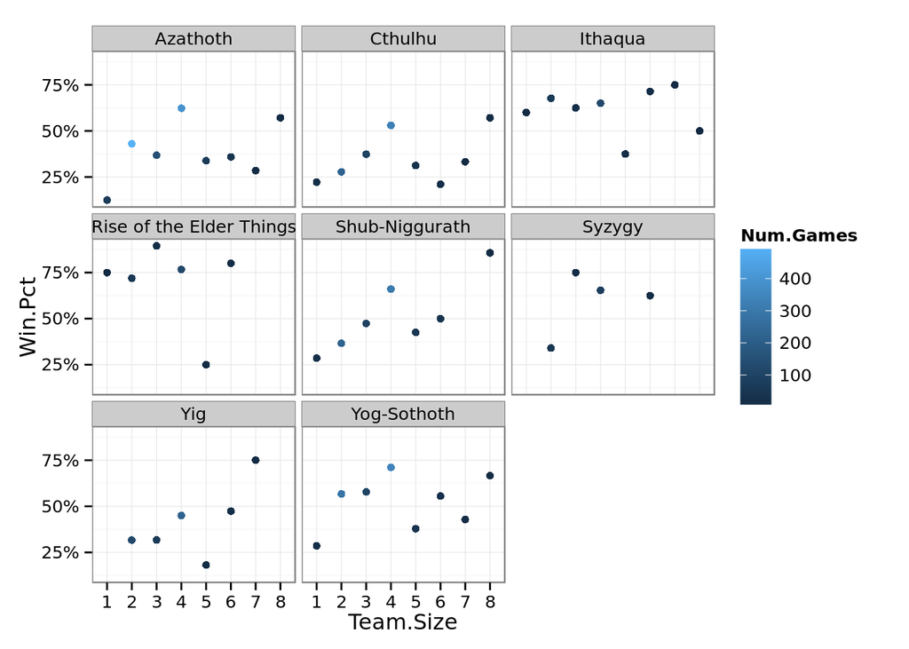

```r
games %>% group_by(Ancient.One, Team.Size, Outcome) %>% tally() %>%
  dcast(Ancient.One + Team.Size ~ Outcome, value.var = "n") %>% group_by(Ancient.One, Team.Size) %>%
  summarize(Win.Pct = Victory / (Defeat + Victory), Num.Games = Defeat + Victory) %>%
  ggplot(aes(Team.Size, Win.Pct, color = Num.Games)) + geom_point() + facet_wrap(~Ancient.One) + theme_bw() +
  scale_y_continuous(labels = percent)
```

We’re starting to get a little granular here, and there isn’t necessarily enough data here to be super confident in our conclusions (only 4 games were reported as 5 investigators vs. Rise of the Elder Things, and only 1 is a win. Fluke? One bad Mythos card being swapped for a good one changes that from 25% to 50%). However, some things are interesting and seem to be a bit more robust - for instance, while Azathoth gets easier as you go from 5 to 6 investigators, Cthulhu actually gets **harder** with 6 investigators. So it’s clear that a model that allows for interactions between variables could help us a bit. This is starting to sound a lot like a **decision tree**. Let’s lean back and let the [rpart](https://cran.r-project.org/web/packages/rpart/index.html) package take a crack at it!

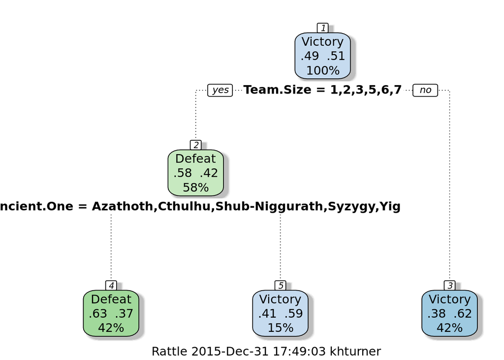

```r
suppressPackageStartupMessages(require(rpart))
dtree <- rpart(Outcome ~ Ancient.One + Team.Size, games)
suppressPackageStartupMessages(require(rattle))
suppressPackageStartupMessages(require(rpart.plot))
suppressPackageStartupMessages(require(RColorBrewer))
fancyRpartPlot(dtree)
```

Cool! So the rpart package seems to have figured out that if you pick 4 or 8 investigators, you have a 62% chance of victory. If not, then as long as you pick an Ancient One that’s not Azathoth, Cthulhu, Shub-Niggurath, Syzygy, or Yig, you’re still more likely to win than lose. How accurate is this model?

```r
Prediction <- ifelse(predict(dtree, games)[,1] >= 0.5, "Defeat?", "Victory?")
table(Prediction, games$Outcome) %>% prop.table %>% diag %>% sum
```

```
## [1] 0.6218451
```

Not bad! About **62.2% accurate**, a ~5% bump over our model that doesn’t allow interactions between variables. But what about that cool blip in Cthulhu difficulty we found? Or the shape of the Win.Pct vs. Team.Size curve for Ithaqua, that’s super weird, maybe there’s something there? Or how about all those other factors, like which investigators are in the team, and which expansions you play with, etc. Wouldn’t more nodes to capture these special cases help? To make deeper trees, we’re going to relax a few parameters, allowing for more nodes to be made.

[figure not shown]

```r
dtree <- rpart(Outcome ~ ., games, control = rpart.control(minsplit = 5, cp = 0.005)) # The '.' means vs. everything else
fancyRpartPlot(dtree)
```

```r
Prediction <- ifelse(predict(dtree, games)[,1] >= 0.5, "Defeat?", "Victory?")
table(Prediction, games$Outcome) %>% prop.table %>% diag %>% sum
```

```
## [1] 0.6409922
```

Another bump! We’re now **64.1% accurate**. So far this is going great! Let’s really open ’er up and build the most crazy deep decision tree to capture all of those little “nuggets of truth” as Trevor Stephens calls them.

```r
dtree <- rpart(Outcome ~ ., games, control = rpart.control(minsplit = 2, cp = 0))
# fancyRpartPlot(dtree) # This plot gets a little out of hand, trust me
Prediction <- ifelse(predict(dtree, games)[,1] >= 0.5, "Defeat?", "Victory?")
table(Prediction, games$Outcome) %>% prop.table %>% diag %>% sum
```

```
## [1] 0.9667102
```

**96.67% accurate**! We are awesome.

But wait, weren’t we talking earlier about how some of this data is pretty noisy? Remember how 3 of the 4 games that were 5 investigators vs. Rise of the Elder Things were losses? Doesn’t that seem weird? How good is our prediction model if we only train it to recognize blips? Or, put another way, how good would this model do on data it has never seen before? This is where we need to introduce some **cross-validation**, or withholding some data for model building and then testing our model on that data. We’ll use the great [caret](http://topepo.github.io/caret/index.html) package to help us.

```r
suppressPackageStartupMessages(require(caret))
set.seed(12345)
trainIndex <- createDataPartition(games$Outcome, p = 0.8, list = F) # Set aside 20% of the data for testing
games.train <- games %>% slice(trainIndex) # Train on 80% of the data
games.test <- games %>% slice(-trainIndex) # Test on the remaining 20%
dtree <- rpart(Outcome ~ ., games.train, control = rpart.control(minsplit = 2, cp = 0))
Prediction <- ifelse(predict(dtree, games.test)[,1] >= 0.5, "Defeat?", "Victory?")
# How accurate are we on our test data?
table(Prediction, games.test$Outcome) %>% prop.table %>% diag %>% sum
```

```
## [1] 0.5821545
```

What’s going on here is we’re [overfitting](https://en.wikipedia.org/wiki/Overfitting) to our noisy data. This is a complex topic, but put simply it means that we built a model that does great on data it’s already seen, and not good against new data. What if one of those 4 games where 5 investigators played against Rise of the Elder Things happened on a bad day for somebody? We might train our model to look for 5 vs. RotET, which would predict our data well, but chances are it’s not as hard as the data would suggest to beat them, so a model trained on that would be less accurate for predicting future cases. So how can we use this general decision tree approach but avoid overfitting?

## Model 2: Random forest classification model of Victory/Defeat

The answer to this question is to use random forests to build our model. They’re fast, they’re easy, and they aren’t as much of a black box as other ML algorithms. If you’re new to random forests, I can’t recommend [Trevor Stephens’ series of blog posts on the Titanic dataset](http://trevorstephens.com/post/72916401642/titanic-getting-started-with-r) enough. Even if you are a complete data science novice, it’s a great read and very easy to follow. He takes you through a series of models of surviving or perishing on the Titanic, from the naive “everyone dies” model, through a slightly more informed “women and children first” model, and finally does some pretty nifty feature engineering and algorithm tuning on random forests. I really enjoyed reading it and I bet you will too. Much of this workflow is cribbed from his work.

Basically though, a random forest is an ensemble of (usually) hundreds of decision trees that are allowed to “vote” on the outcome to generate a prediction. Here I will steal an image from Trevor Stephens’ blog post:

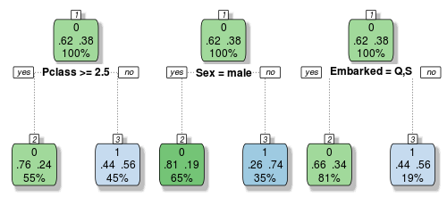

> Each of these trees make their classification decisions based on different variables. So let’s imagine a female passenger from Southampton who rode in first class. Tree one and two would vote that she survived, but tree three votes that she perishes. If we take a vote, it’s 2 to 1 in favour of her survival, so we would classify this passenger as a survivor.

And just like above, with more nodes, we can start to capture interactions between variables. One additional nice thing about random forests is that they don’t really suffer much when you add in uninformative variables. So the first thing we can do is just let it rip on our data!

```r
suppressPackageStartupMessages(require(randomForest))
rf <- randomForest(Outcome ~ ., games.train, importance = T, type = "prob")
Prediction <- predict(rf, games.test)
table(Prediction, games.test$Outcome) %>% prop.table %>% diag %>% sum
```

```
## [1] 0.6278564
```

```r
varImp(rf) %>% add_rownames("Feature") %>% arrange(-Defeat)
```

```
## Source: local data frame [32 x 3]
##
##          Feature    Defeat   Victory
##            (chr)     (dbl)     (dbl)
## 1      Team.Size 31.003417 31.003417
## 2    Ancient.One 16.527224 16.527224
## 3        Charlie  8.875339  8.875339
## 4         Akachi  7.861540  7.861540
## 5           Mark  7.623216  7.623216
## 6  Forsaken.Lore  5.038695  5.038695
## 7         Ursula  4.996066  4.996066
## 8            Leo  4.127610  4.127610
## 9          Daisy  3.977370  3.977370
## 10         Trish  3.968831  3.968831
## ..           ...       ...       ...
```

This is essentially a measure of how informative each feature is when it’s used as a split in the trees in our forest. Another thing I like to do with these is ask for the probabilistic information back (the `type="prob"` parameter above). Let’s see whether it’s more right when it’s more sure of its call:

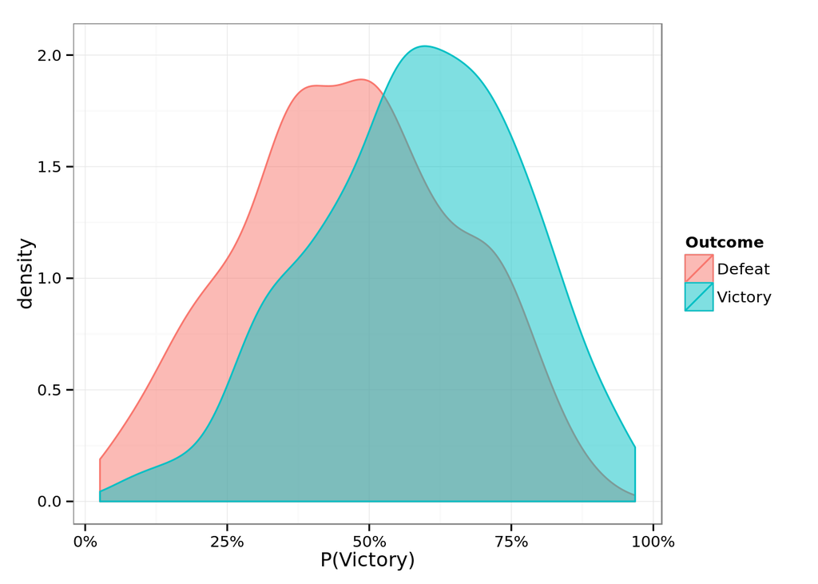

```r
Prediction <- predict(rf, games.test, type = "prob") %>% as.data.frame %>% tbl_df
Prediction$Outcome <- games.test$Outcome
Prediction %>% ggplot(aes(Victory, fill = Outcome, color = Outcome)) + geom_density(alpha = 0.5) + theme_bw() +
  scale_x_continuous(labels = percent) + xlab("P(Victory)")
```

This is a density plot (think of it like a histogram). Interestingly, there’s a pretty big overlap; the model can be wrong even when it’s super sure one way or the other.

We have one last thing to look into for our forest: `mtry`, which affects how deep each tree is in the forest. Let’s look into tweaking those:

```r
tuneRF(select(games, -Outcome), games$Outcome, ntreeTry = 250, plot = F)
```

```
## mtry = 5  OOB error = 37.25%
## Searching left ...
## mtry = 3     OOB error = 36.53%
## 0.0192757 0.05
## Searching right ...
## mtry = 10    OOB error = 37.45%
## -0.005257009 0.05
```

```
##        mtry  OOBError
## 3.OOB     3 0.3653177
## 5.OOB     5 0.3724978
## 10.OOB   10 0.3744560
```

OK, well, it looks like the default value works fine! So let’s build that final model on all of our data and save it:

```r
rf_outcome <- randomForest(Outcome ~ ., games, type = "prob")
saveRDS(rf_outcome, "FinalEldritchModel.Outcome.rds.gz", compress = T)
```

## Model 2.5: Random forest classification model of type of Victory or Defeat

This isn’t super complicated, we’re basically going to replace Outcome (Victory/Defeat) with Result (Victory by slumber Mysteries, etc.) and repeat the process.

```r
games <- readRDS("EldritchData.rds.gz") %>% select(-Outcome)
trainIndex <- createDataPartition(games$Result, p = 0.8, list = F) # Set aside 20% of the data for testing
games.train <- games %>% slice(trainIndex) # Train on 80% of the data
games.test <- games %>% slice(-trainIndex) # Test on the remaining 20%
rf <- randomForest(Result ~ ., games.train, importance = T, type = "prob")
Prediction <- predict(rf, games.test)
table(Prediction, games.test$Result) %>% prop.table %>% diag %>% sum
```

```
## [1] 0.5032751
```

So at **~50% accuracy here**, it’s pretty clear that it’s easier to predict whether you win or lose than how you win or lose. But that’s still not too bad! Could be interesting to include; what if you’re really dying to play a game where you win by Final Mystery? Let’s see what features affect the prediction of the type of victory or defeat you get:

```r
varImp(rf) %>% add_rownames("Feature") %>% arrange(-`Defeat by awakened Ancient One`)
```

```
## Source: local data frame [32 x 8]
##
##             Feature Defeat by awakened Ancient One Defeat by elimination
##               (chr)                          (dbl)                 (dbl)
## 1         Team.Size                      30.795787            14.8581693
## 2       Ancient.One                      23.119447            20.4056341
## 3              Tony                      10.133628            -0.2788198
## 4              Mark                       9.952151             6.4670409
## 5             Agnes                       8.794588             3.4198315
## 6  Strange.Remnants                       8.419769            -3.7329386
## 7               Leo                       6.582276             4.7236263
## 8               Jim                       6.441804             1.6074692
## 9           Charlie                       6.034526             7.9355201
## 10            Diana                       5.896304             2.5870345
## ..              ...                            ...                   ...
## Variables not shown: Defeat by forfeit (dbl), Defeat by Mythos depletion
##   (dbl), Defeat by Rumor (dbl), Victory by Final Mystery (dbl), Victory by
##   slumber Mysteries (dbl)
```

I’ll skip the mtry tuning (trust me that it doesn’t affect much, like above), we’ll build the final model here too and save it.

```r
rf_result <- randomForest(Result ~ ., games, type = "prob")
saveRDS(rf_result, "FinalEldritchModel.Result.rds.gz", compress = T)
```